# Project 3 - Body performance Data

Nhom22: Vũ Xuân Hiệp-22110060 Trần Duy An-22110007 Phạm Xuân Bách-22110021 Nguyễn Tất Chiến-22110028 Phạm Thái Thiên An-22110005

2025-01-08

# “Project 3 - Body performance Data”

## 1. EDA

### a.Import các thư viện

```r
#update.packages('rsample')
```

```r
library(boot)
library(rsample)
library(tidyverse)
library(matrixStats)
library(lubridate)
library(janitor)
```

```r
library(ggplot2)
library(corrplot)
library(dplyr)
library(splines2)
library(mgcv)
library(mgcViz)
library(leaps)
library(gridExtra)
library(grid)
library(MASS)
library(leaps)
library(lmPerm)
library(corrplot)
library(DataExplorer)
library(caret)
library(mgcv)
library(mgcViz)
library(splines)
library(lmPerm)
library(ggridges)
library(ggbeeswarm)
library(gridExtra)
library(readr)
library(randomForest)
library(dplyr)
library(VIM)
library(knitr)
library(car)
library(FSA)
```

### b.Đọc dữ liệu

```r
locale=locale(encoding="latin1")
data <- read_csv(file = "bodyPerformance.csv", locale = locale)
head(data)
```

```
## # A tibble: 6 × 12
##     age gender height_cm weight_kg `body fat_%` diastolic systolic gripForce
##   <dbl> <chr>      <dbl>     <dbl>        <dbl>     <dbl>    <dbl>     <dbl>
## 1    27 M           172.      75.2         21.3        80      130      54.9
## 2    25 M           165       55.8         15.7        77      126      36.4
## 3    31 M           180.      78           20.1        92      152      44.8
## 4    32 M           174.      71.1         18.4        76      147      41.4
## 5    28 M           174.      67.7         17.1        70      127      43.5
## 6    36 F           165.      55.4         22          64      119      23.8
## # ℹ 4 more variables: `sit and bend forward_cm` <dbl>, `sit-ups counts` <dbl>,
## #   `broad jump_cm` <dbl>, class <chr>
```

```r
data <- data |> janitor::clean_names()
glimpse(data)
```

```
## Rows: 13,393
## Columns: 12
## $ age                     <dbl> 27, 25, 31, 32, 28, 36, 42, 33, 54, 28, 42, 57…
## $ gender                  <chr> "M", "M", "M", "M", "M", "F", "F", "M", "M", "…
## $ height_cm               <dbl> 172.3, 165.0, 179.6, 174.5, 173.8, 165.4, 164.…
## $ weight_kg               <dbl> 75.24, 55.80, 78.00, 71.10, 67.70, 55.40, 63.7…
## $ body_fat_percent        <dbl> 21.3, 15.7, 20.1, 18.4, 17.1, 22.0, 32.2, 36.9…
## $ diastolic               <dbl> 80, 77, 92, 76, 70, 64, 72, 84, 85, 81, 63, 69…
## $ systolic                <dbl> 130, 126, 152, 147, 127, 119, 135, 137, 165, 1…
## $ grip_force              <dbl> 54.9, 36.4, 44.8, 41.4, 43.5, 23.8, 22.7, 45.9…
## $ sit_and_bend_forward_cm <dbl> 18.4, 16.3, 12.0, 15.2, 27.1, 21.0, 0.8, 12.3,…
## $ sit_ups_counts          <dbl> 60, 53, 49, 53, 45, 27, 18, 42, 34, 55, 68, 0,…
## $ broad_jump_cm           <dbl> 217, 229, 181, 219, 217, 153, 146, 234, 148, 2…
## $ class                   <chr> "C", "A", "C", "B", "B", "B", "D", "B", "C", "…
```

```r
data2 <- data
```

### c.EDA:

## i.Bảng tổng hợp dữ liệu:

### Phân tích dữ liệu thăm dò & kiểm tra cấu trúc của tập dữ liệu

```r
str(data)
```

```
## spc_tbl_ [13,393 × 12] (S3: spec_tbl_df/tbl_df/tbl/data.frame)
##  $ age                    : num [1:13393] 27 25 31 32 28 36 42 33 54 28 ...
##  $ gender                 : chr [1:13393] "M" "M" "M" "M" ...
##  $ height_cm              : num [1:13393] 172 165 180 174 174 ...
##  $ weight_kg              : num [1:13393] 75.2 55.8 78 71.1 67.7 ...
##  $ body_fat_percent       : num [1:13393] 21.3 15.7 20.1 18.4 17.1 22 32.2 36.9 27.6 14.4 ...
##  $ diastolic              : num [1:13393] 80 77 92 76 70 64 72 84 85 81 ...
##  $ systolic               : num [1:13393] 130 126 152 147 127 119 135 137 165 156 ...
##  $ grip_force             : num [1:13393] 54.9 36.4 44.8 41.4 43.5 23.8 22.7 45.9 40.4 57.9 ...
##  $ sit_and_bend_forward_cm: num [1:13393] 18.4 16.3 12 15.2 27.1 21 0.8 12.3 18.6 12.1 ...
##  $ sit_ups_counts         : num [1:13393] 60 53 49 53 45 27 18 42 34 55 ...
##  $ broad_jump_cm          : num [1:13393] 217 229 181 219 217 153 146 234 148 213 ...
##  $ class                  : chr [1:13393] "C" "A" "C" "B" ...
##  - attr(*, "spec")=
##   .. cols(
##   ..   age = col_double(),
##   ..   gender = col_character(),
##   ..   height_cm = col_double(),
##   ..   weight_kg = col_double(),
##   ..   `body fat_%` = col_double(),
##   ..   diastolic = col_double(),
##   ..   systolic = col_double(),
##   ..   gripForce = col_double(),
##   ..   `sit and bend forward_cm` = col_double(),
##   ..   `sit-ups counts` = col_double(),
##   ..   `broad jump_cm` = col_double(),
##   ..   class = col_character()
##   .. )
##  - attr(*, "problems")=<externalptr>
```

### Hiển thị một vài hàng đầu tiên của tập dữ liệu

```r
head(data)
```

```
## # A tibble: 6 × 12
##     age gender height_cm weight_kg body_fat_percent diastolic systolic
##   <dbl> <chr>      <dbl>     <dbl>            <dbl>     <dbl>    <dbl>
## 1    27 M           172.      75.2             21.3        80      130
## 2    25 M           165       55.8             15.7        77      126
## 3    31 M           180.      78               20.1        92      152
## 4    32 M           174.      71.1             18.4        76      147
## 5    28 M           174.      67.7             17.1        70      127
## 6    36 F           165.      55.4             22          64      119
## # ℹ 5 more variables: grip_force <dbl>, sit_and_bend_forward_cm <dbl>,
## #   sit_ups_counts <dbl>, broad_jump_cm <dbl>, class <chr>
```

### Kiểm tra phần trăm bị khuyết trong dữ liệu

```r
aggr(data, ylab = c("Proportion of missings", "Pattern"), number = TRUE,
cex.axis = 0.4, cex.numbers = 0.5)
```

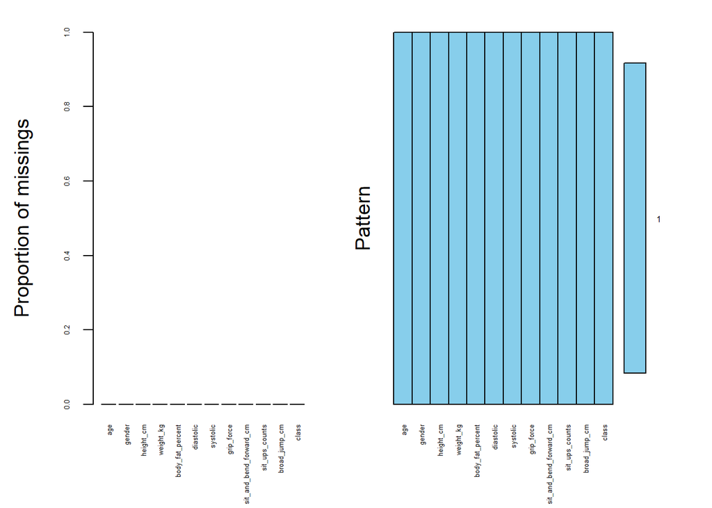

### Kết quả tổng hợp

```r
summary(data)
```

```
##       age           gender            height_cm       weight_kg
##  Min.   :21.00   Length:13393       Min.   :125.0   Min.   : 26.30
##  1st Qu.:25.00   Class :character   1st Qu.:162.4   1st Qu.: 58.20
##  Median :32.00   Mode  :character   Median :169.2   Median : 67.40
##  Mean   :36.78                      Mean   :168.6   Mean   : 67.45
##  3rd Qu.:48.00                      3rd Qu.:174.8   3rd Qu.: 75.30
##  Max.   :64.00                      Max.   :193.8   Max.   :138.10
##  body_fat_percent   diastolic        systolic       grip_force
##  Min.   : 3.00    Min.   :  0.0   Min.   :  0.0   Min.   : 0.00
##  1st Qu.:18.00    1st Qu.: 71.0   1st Qu.:120.0   1st Qu.:27.50
##  Median :22.80    Median : 79.0   Median :130.0   Median :37.90
##  Mean   :23.24    Mean   : 78.8   Mean   :130.2   Mean   :36.96
##  3rd Qu.:28.00    3rd Qu.: 86.0   3rd Qu.:141.0   3rd Qu.:45.20
##  Max.   :78.40    Max.   :156.2   Max.   :201.0   Max.   :70.50
##  sit_and_bend_forward_cm sit_ups_counts  broad_jump_cm      class
##  Min.   :-25.00          Min.   : 0.00   Min.   :  0.0   Length:13393
##  1st Qu.: 10.90          1st Qu.:30.00   1st Qu.:162.0   Class :character
##  Median : 16.20          Median :41.00   Median :193.0   Mode  :character
##  Mean   : 15.21          Mean   :39.77   Mean   :190.1
##  3rd Qu.: 20.70          3rd Qu.:50.00   3rd Qu.:221.0
##  Max.   :213.00          Max.   :80.00   Max.   :303.0
```

## ii.Xử lí dữ liệu:

### Kiểm tra tổng thể dữ liệu

```r
# Hàm để lấy thông tin dữ liệu bao gồm loại dữ liệu, giá trị duy nhất,và giá trị null
datainfo <- function(data) {
# Tạo một khung dữ liệu để lưu trữ thông tin
temp_ps <- data.frame(matrix(ncol = 6, nrow = ncol(data)))
colnames(temp_ps) <- c("Column_Name", "DataType",
"Non_null_Values", "Unique_Values", "NaN_Values_Percentage",
"Duplicates")
# Điền thông tin vào khung dữ liệu
temp_ps$Column_Name <- colnames(data) # Lấy tên các cột
temp_ps$DataType <- sapply(data, class) # Lấy loại dữ liệu sử dụng
sapply
temp_ps$Non_null_Values <- sapply(data, function(x)
sum(!is.na(x))) # Đếm số giá trị không null sử dụng sapply và is.na
temp_ps$Unique_Values <- sapply(data, function(x)
length(unique(na.omit(x)))) # Đếm số giá trị duy nhất loại bỏ các giá trị NA
temp_ps$NaN_Values <- sapply(data, function(x) sum(is.na(x))) #Đếm số giá trị null sử dụng sapply và is.na
temp_ps$NaN_Values_Percentage <- (temp_ps$NaN_Values /
nrow(data)) * 100 # Tính tỷ lệ phần trăm của các giá trị null
# Đếm số lượng bản ghi bị trùng lặp trong dữ liệu
temp_ps$Duplicates <- sum(duplicated(data))
# Trả về khung dữ liệu chứa thông tin
return(temp_ps)
}
data_info <- datainfo(data)
print(data_info)
```

```
##                Column_Name  DataType Non_null_Values Unique_Values
## 1                      age   numeric           13393            44
## 2                   gender character           13393             2
## 3                height_cm   numeric           13393           467
## 4                weight_kg   numeric           13393          1398
## 5         body_fat_percent   numeric           13393           527
## 6                diastolic   numeric           13393            89
## 7                 systolic   numeric           13393           102
## 8               grip_force   numeric           13393           550
## 9  sit_and_bend_forward_cm   numeric           13393           528
## 10          sit_ups_counts   numeric           13393            81
## 11           broad_jump_cm   numeric           13393           245
## 12                   class character           13393             4
##    NaN_Values_Percentage Duplicates NaN_Values
## 1                      0          1          0
## 2                      0          1          0
## 3                      0          1          0
## 4                      0          1          0
## 5                      0          1          0
## 6                      0          1          0
## 7                      0          1          0
## 8                      0          1          0
## 9                      0          1          0
## 10                     0          1          0
## 11                     0          1          0
## 12                     0          1          0
```

=> Bộ dữ liệu không chứa NaN

### Kiểm tra giá trị bất hợp lý (giá trị = 0) trong các cột cần loại bỏ

```r
invalid_rows <- with(data,
                     diastolic == 0 |
                     systolic == 0 |
                     grip_force == 0 |
                     sit_and_bend_forward_cm == 0 |
                     sit_ups_counts == 0 |
                     broad_jump_cm == 0)
```

### Loại bỏ các hàng có giá trị bất hợp lý

```r
data1 <- data[!invalid_rows, ]
```

### Xem kích thước dữ liệu trước và sau khi làm sạch

```r
cat("Số hàng trước khi làm sạch:", nrow(data), "\n")
```

```
## Số hàng trước khi làm sạch: 13393
```

```r
cat("Số hàng sau khi làm sạch:", nrow(data1), "\n")
```

```
## Số hàng sau khi làm sạch: 13248
```

### Kiểm tra hàm class với avg_grip_force và total_sit_ups

```r
result <- data1 %>%
  group_by(class) %>%
  summarise(
    avg_grip_force = mean(grip_force, na.rm = TRUE),
    total_sit_ups = sum(sit_ups_counts, na.rm = TRUE)
  ) %>%
  arrange(desc(avg_grip_force)) %>%
  ungroup()

print(result)
```

```
## # A tibble: 4 × 3
##   class avg_grip_force total_sit_ups
##   <chr>          <dbl>         <dbl>
## 1 A               38.6       160196
## 2 B               37.9       142670.
## 3 C               36.6       129460
## 4 D               35.2        99597.
```

### Chuyển đổi kiểu dữ liệu cho các biến class, gender

```r
data <- data1 |> mutate(
  gender = as.factor(gender),
  class = as.factor(class)
)
data
```

```
## # A tibble: 13,248 × 12
##      age gender height_cm weight_kg body_fat_percent diastolic systolic
##    <dbl> <fct>      <dbl>     <dbl>            <dbl>     <dbl>    <dbl>
##  1    27 M           172.      75.2             21.3        80      130
##  2    25 M           165       55.8             15.7        77      126
##  3    31 M           180.      78               20.1        92      152
##  4    32 M           174.      71.1             18.4        76      147
##  5    28 M           174.      67.7             17.1        70      127
##  6    36 F           165.      55.4             22          64      119
##  7    42 F           164.      63.7             32.2        72      135
##  8    33 M           175.      77.2             36.9        84      137
##  9    54 M           167.      67.5             27.6        85      165
## 10    28 M           185       84.6             14.4        81      156
## # ℹ 13,238 more rows
## # ℹ 5 more variables: grip_force <dbl>, sit_and_bend_forward_cm <dbl>,
## #   sit_ups_counts <dbl>, broad_jump_cm <dbl>, class <fct>
```

```r
summary(data$class)
```

```
##    A    B    C    D
## 3348 3346 3344 3210
```

```r
summary(data$gender)
```

```
##    F    M
## 4800 8448
```

## iii.Trực quan dữ liệu:

### histogram cho tất cả các biến định lượng

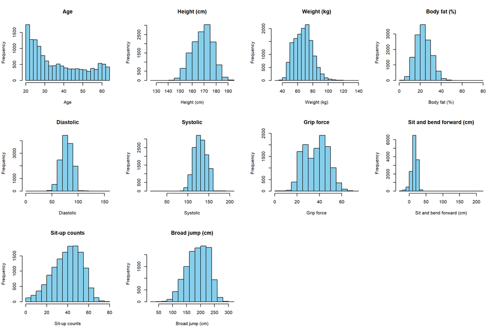

```r
# Xác định các cột định lượng
num_cols <- unlist(lapply(data, is.numeric))         # Lọc cột số
data_num <- data[, num_cols]                        # Chỉ giữ các cột định lượng

# Đặt tên cột dễ đọc hơn (nếu cần)
colnames(data_num) <- c('Age', 'Height (cm)', 'Weight (kg)', 'Body fat (%)',
                        'Diastolic', 'Systolic', 'Grip force',
                        'Sit and bend forward (cm)', 'Sit-up counts', 'Broad jump (cm)')

# Vẽ histogram cho từng biến định lượng trong cùng một khung hình
par(mfrow = c(3, 4))  # Chia khung hình thành 3 hàng và 4 cột
for (i in 1:ncol(data_num)) {
  hist(data_num[[i]],
       main = colnames(data_num)[i],
       xlab = colnames(data_num)[i],
       col = 'skyblue',
       border = 'black',
       breaks = 20)
}
```

### Vẽ biểu đồ barchart so sánh số lượng phần tử trong nhóm theo giới tính

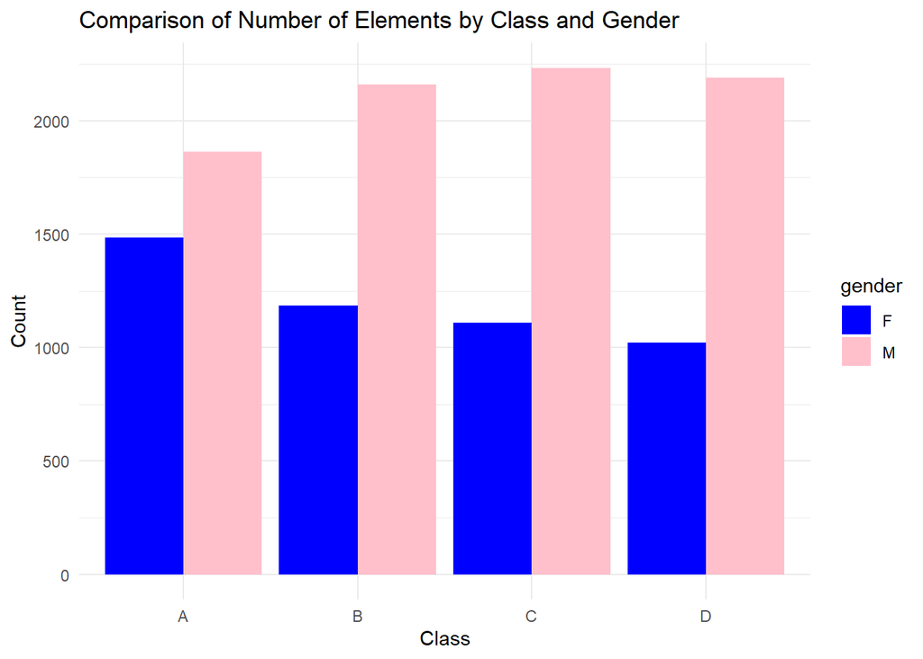

```r
ggplot(data, aes(x = class, fill = gender)) +
  geom_bar(position = "dodge") +  # Dùng geom_bar để vẽ biểu đồ cột, "dodge" giúp các cột cạnh nhau
  scale_x_discrete(limits = c("A", "B", "C", "D")) +  # Đảm bảo thứ tự của các nhóm
  scale_fill_manual(values = c("blue", "pink")) +  # Chọn màu cho giới tính nam (blue) và nữ (pink)
  theme_minimal() +  # Dùng theme tối giản
  labs(
    x = "Class",  # Nhãn trục x
    y = "Count",  # Nhãn trục y (số lượng)
    title = "Comparison of Number of Elements by Class and Gender"  # Tiêu đề
  )
```

=>Số lượng Nam giới đạt nhóm A còn thấp so với các nhóm khác, trong khi đó số lượng Nữ giới đạt nhóm A cao nhất.

#Tạo hàm Tính BMI và MAP

```r
calculate_bmi <- function(weight, height) {
  # Đảm bảo chiều cao được chuyển đổi sang mét
  height_m <- height / 100

  # Tính toán BMI
  bmi <- weight / height_m^2

  return(bmi)
}
calculate_map <- function(data, diastolic, systolic) {
  # Kiểm tra các cột có tồn tại trong dữ liệu
  if (!(diastolic %in% names(data)) || !(systolic %in% names(data))) {
    stop("Cột diastolic hoặc systolic không tồn tại trong dữ liệu.")
  }

  # Tính MAP và thêm cột mới vào dataframe
  data$MAP <- data[[diastolic]] + (data[[systolic]] - data[[diastolic]]) / 3
  return(data)
}
```

### Hàm để loại bỏ giá trị ngoại lai dựa trên IQR và Tính toán BMI

```r
remove_outliers <- function(df, cols) {
  for (col in cols) {
    if (is.numeric(df[[col]])) {
      Q1 <- quantile(df[[col]], 0.25, na.rm = TRUE) # Quartile 1
      Q3 <- quantile(df[[col]], 0.75, na.rm = TRUE) # Quartile 3
      IQR <- Q3 - Q1 # Interquartile Range
      lower_bound <- Q1 - 1.5 * IQR
      upper_bound <- Q3 + 1.5 * IQR
      # Giữ lại các giá trị không phải ngoại lai
      df <- df[df[[col]] >= lower_bound & df[[col]] <= upper_bound, ]
    }
  }
  return(df)
}

# Xác định các cột số
numeric_cols <- sapply(data, is.numeric)

# Loại bỏ giá trị ngoại lai
data_cleaned <- remove_outliers(data, names(data)[numeric_cols])
data_cleaned
```

```
## # A tibble: 12,619 × 12
##      age gender height_cm weight_kg body_fat_percent diastolic systolic
##    <dbl> <fct>      <dbl>     <dbl>            <dbl>     <dbl>    <dbl>
##  1    27 M           172.      75.2             21.3        80      130
##  2    25 M           165       55.8             15.7        77      126
##  3    31 M           180.      78               20.1        92      152
##  4    32 M           174.      71.1             18.4        76      147
##  5    28 M           174.      67.7             17.1        70      127
##  6    36 F           165.      55.4             22          64      119
##  7    42 F           164.      63.7             32.2        72      135
##  8    33 M           175.      77.2             36.9        84      137
##  9    54 M           167.      67.5             27.6        85      165
## 10    28 M           185       84.6             14.4        81      156
## # ℹ 12,609 more rows
## # ℹ 5 more variables: grip_force <dbl>, sit_and_bend_forward_cm <dbl>,
## #   sit_ups_counts <dbl>, broad_jump_cm <dbl>, class <fct>
```

```r
max_value <- max(data$age)
min_value <- min(data$age)

print(max_value)
```

```
## [1] 64
```

```r
print(min_value)
```

```
## [1] 21
```

```r
data_cleaned$age_group <- cut(data_cleaned$age,
                      breaks = c(21, 30, 40, 50, 64),
                      labels = c("21-32","33-44", "45-56",D= "56-64"),
                      right = TRUE,
                      include.lowest = TRUE)

data_cleaned$BMI <- calculate_bmi(data_cleaned$weight_kg, data_cleaned$height_cm)
```

```r
summary(data_cleaned$class)
```

```
##    A    B    C    D
## 3318 3314 3322 2665
```

### Chỉ số cơ thể và Chỉ số thể chất

[figure not shown]

```r
data_cleaned$BMI <- calculate_bmi(data_cleaned$weight_kg, data_cleaned$height_cm)
par(mfrow = c(2, 2),mar = c(5, 4, 2, 1),mgp = c(3, 1, 0),oma = c(0, 0, 3, 0))
boxplot(BMI ~ age_group, data = data_cleaned, col = rainbow(4), main = "BMI",cex.axis = 0.8)
boxplot(diastolic ~ age_group, data = data_cleaned, col = rainbow(4), main = "Diastolic",cex.axis = 0.8)
boxplot(systolic ~ age_group, data = data_cleaned, col = rainbow(4), main = "Systolic",cex.axis = 0.8)
boxplot(body_fat_percent ~ age_group, data = data_cleaned, col = rainbow(4), main = "Body fat",cex.axis = 0.8)
mtext("Chỉ số cơ thể",
      outer = TRUE, line = 1, cex = 1.5)
```

[figure not shown]

```r
par(mfrow = c(2, 2),mar = c(5, 4, 2, 1),mgp = c(3, 1, 0),oma = c(0, 0, 3, 0))
boxplot(grip_force ~ age_group, data = data_cleaned, col = rainbow(4), main = "Grip Force",cex.axis = 0.8)
boxplot(broad_jump_cm ~ age_group, data = data_cleaned, col = rainbow(4), main = "Broad Jump",cex.axis = 0.8)
boxplot(sit_ups_counts ~ age_group, data = data_cleaned, col = rainbow(4), main = "Sit-ups Counts",cex.axis = 0.8)
boxplot(sit_and_bend_forward_cm ~ age_group, data = data_cleaned, col = rainbow(4), main = "Sit and Bend Forward_cm",cex.axis = 0.8)
mtext("Chỉ số thể chất",
      outer = TRUE, line = 1, cex = 1.5)
```

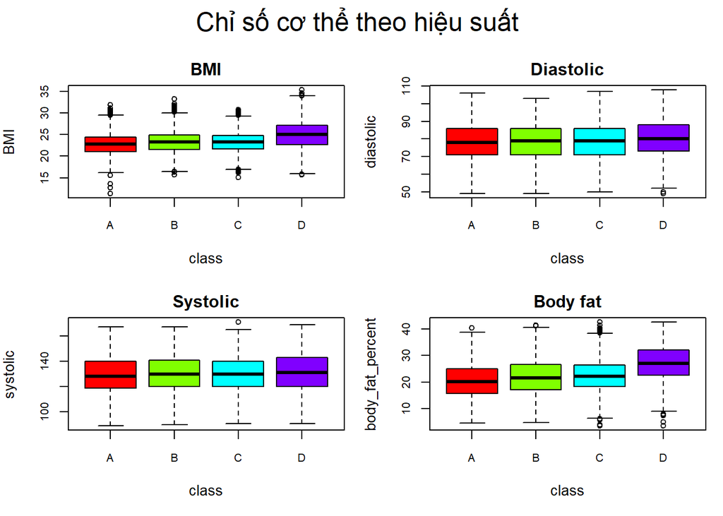

```r
par(mfrow = c(2, 2),mar = c(5, 4, 2, 1),mgp = c(3, 1, 0),oma = c(0, 0, 3, 0))
boxplot(BMI ~ class, data = data_cleaned, col = rainbow(4), main = "BMI",cex.axis = 0.8)
boxplot(diastolic ~ class, data = data_cleaned, col = rainbow(4), main = "Diastolic",cex.axis = 0.8)
boxplot(systolic ~ class, data = data_cleaned, col = rainbow(4), main = "Systolic",cex.axis = 0.8)
boxplot(body_fat_percent ~ class, data = data_cleaned, col = rainbow(4), main = "Body fat",cex.axis = 0.8)
mtext("Chỉ số cơ thể theo hiệu suất ",
      outer = TRUE, line = 1, cex = 1.5)
```

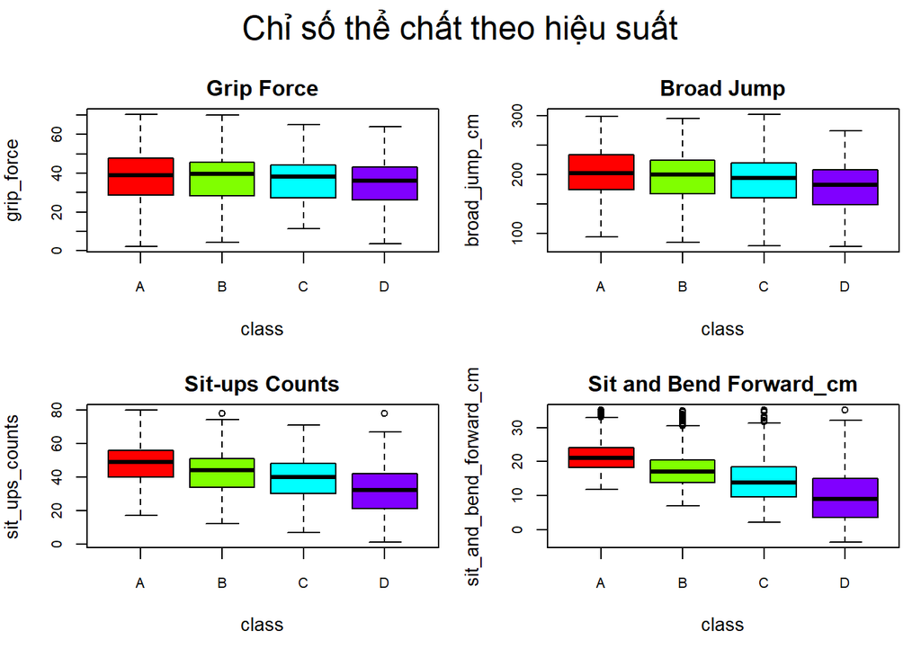

```r
par(mfrow = c(2, 2),mar = c(5, 4, 2, 1),mgp = c(3, 1, 0),oma = c(0, 0, 3, 0))
boxplot(grip_force ~ class, data = data_cleaned, col = rainbow(4), main = "Grip Force",cex.axis = 0.8)
boxplot(broad_jump_cm ~ class, data = data_cleaned, col = rainbow(4), main = "Broad Jump",cex.axis = 0.8)
boxplot(sit_ups_counts ~ class, data = data_cleaned, col = rainbow(4), main = "Sit-ups Counts",cex.axis = 0.8)
boxplot(sit_and_bend_forward_cm ~ class, data = data_cleaned, col = rainbow(4), main = "Sit and Bend Forward_cm",cex.axis = 0.8)
mtext("Chỉ số thể chất theo hiệu suất",
      outer = TRUE, line = 1, cex = 1.5)
```

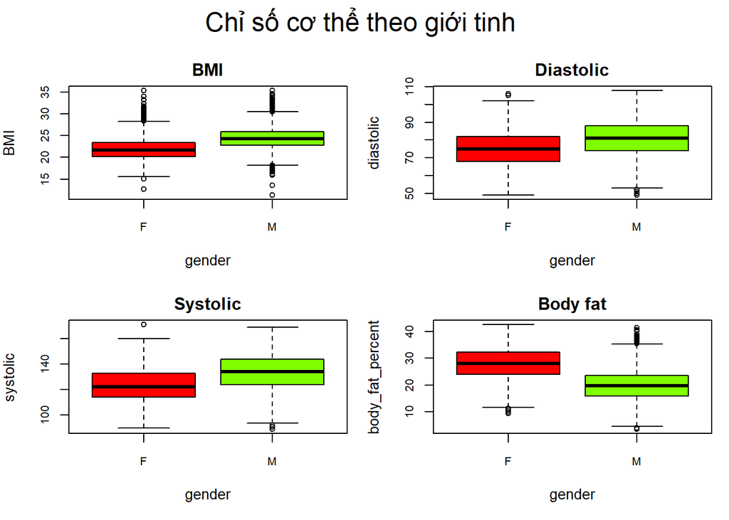

```r
par(mfrow = c(2, 2),mar = c(5, 4, 2, 1),mgp = c(3, 1, 0),oma = c(0, 0, 3, 0))
boxplot(BMI ~ gender, data = data_cleaned, col = rainbow(4), main = "BMI",cex.axis = 0.8)
boxplot(diastolic ~ gender, data = data_cleaned, col = rainbow(4), main = "Diastolic",cex.axis = 0.8)
boxplot(systolic ~ gender, data = data_cleaned, col = rainbow(4), main = "Systolic",cex.axis = 0.8)
boxplot(body_fat_percent ~ gender, data = data_cleaned, col = rainbow(4), main = "Body fat",cex.axis = 0.8)
mtext("Chỉ số cơ thể theo giới tinh ",
      outer = TRUE, line = 1, cex = 1.5)
```

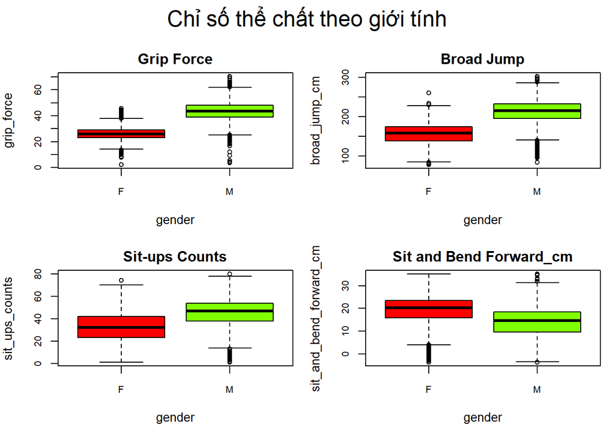

```r
par(mfrow = c(2, 2),mar = c(5, 4, 2, 1),mgp = c(3, 1, 0),oma = c(0, 0, 3, 0))
boxplot(grip_force ~ gender, data = data_cleaned, col = rainbow(4), main = "Grip Force",cex.axis = 0.8)
boxplot(broad_jump_cm ~ gender, data = data_cleaned, col = rainbow(4), main = "Broad Jump",cex.axis = 0.8)
boxplot(sit_ups_counts ~ gender, data = data_cleaned, col = rainbow(4), main = "Sit-ups Counts",cex.axis = 0.8)
boxplot(sit_and_bend_forward_cm ~ gender, data = data_cleaned, col = rainbow(4), main = "Sit and Bend Forward_cm",cex.axis = 0.8)
mtext("Chỉ số thể chất theo giới tính",
      outer = TRUE, line = 1, cex = 1.5)
```

### Ma trận tương quan

```r
numeric_data <- data_cleaned[, sapply(data_cleaned, is.numeric)]
# Tính ma trận tương quan Pearson
cor_matrix <- cor(numeric_data, use = "complete.obs", method = "pearson")

# In ma trận tương quan
print(cor_matrix)
```

```
##                                 age  height_cm   weight_kg body_fat_percent
## age                      1.00000000 -0.2733413 -0.09010027       0.22978985
## height_cm               -0.27334128  1.0000000  0.75330350      -0.53147162
## weight_kg               -0.09010027  0.7533035  1.00000000      -0.14894017
## body_fat_percent         0.22978985 -0.5314716 -0.14894017       1.00000000
## diastolic                0.16133454  0.1496721  0.26178100       0.03920199
## systolic                 0.20756829  0.2231281  0.34825841      -0.05013393
## grip_force              -0.16138689  0.7351706  0.73155896      -0.55150004
## sit_and_bend_forward_cm -0.09237318 -0.2401860 -0.30409360      -0.02244622
## sit_ups_counts          -0.53920258  0.5009012  0.34271788      -0.59092290
## broad_jump_cm           -0.42187899  0.6848982  0.53432528      -0.67275890
## BMI                      0.10149955  0.2722304  0.83464574       0.22026754
##                           diastolic    systolic grip_force
## age                      0.16133454  0.20756829 -0.1613869
## height_cm                0.14967211  0.22312811  0.7351706
## weight_kg                0.26178100  0.34825841  0.7315590
## body_fat_percent         0.03920199 -0.05013393 -0.5515000
## diastolic                1.00000000  0.67508228  0.2082807
## systolic                 0.67508228  1.00000000  0.2983283
## grip_force               0.20828070  0.29832826  1.0000000
## sit_and_bend_forward_cm -0.08948609 -0.10887763 -0.1601214
## sit_ups_counts           0.02341823  0.07222499  0.5736659
## broad_jump_cm            0.10584868  0.17103570  0.7542052
## BMI                      0.26187737  0.32813067  0.4625954
##                         sit_and_bend_forward_cm sit_ups_counts broad_jump_cm
## age                                 -0.09237318    -0.53920258   -0.42187899
## height_cm                           -0.24018605     0.50090121    0.68489821
## weight_kg                           -0.30409360     0.34271788    0.53432528
## body_fat_percent                    -0.02244622    -0.59092290   -0.67275890
## diastolic                           -0.08948609     0.02341823    0.10584868
## systolic                            -0.10887763     0.07222499    0.17103570
## grip_force                          -0.16012137     0.57366587    0.75420517
## sit_and_bend_forward_cm              1.00000000     0.13918930   -0.02730089
## sit_ups_counts                       0.13918930     1.00000000    0.73770198
## broad_jump_cm                       -0.02730089     0.73770198    1.00000000
## BMI                                 -0.25112563     0.08715464    0.21855339
##                                 BMI
## age                      0.10149955
## height_cm                0.27223035
## weight_kg                0.83464574
## body_fat_percent         0.22026754
## diastolic                0.26187737
## systolic                 0.32813067
## grip_force               0.46259536
## sit_and_bend_forward_cm -0.25112563
## sit_ups_counts           0.08715464
## broad_jump_cm            0.21855339
## BMI                      1.00000000
```

```r
data_unique<- unique(cor_matrix)
print(data_unique)
```

```
##                                 age  height_cm   weight_kg body_fat_percent
## age                      1.00000000 -0.2733413 -0.09010027       0.22978985
## height_cm               -0.27334128  1.0000000  0.75330350      -0.53147162
## weight_kg               -0.09010027  0.7533035  1.00000000      -0.14894017
## body_fat_percent         0.22978985 -0.5314716 -0.14894017       1.00000000
## diastolic                0.16133454  0.1496721  0.26178100       0.03920199
## systolic                 0.20756829  0.2231281  0.34825841      -0.05013393
## grip_force              -0.16138689  0.7351706  0.73155896      -0.55150004
## sit_and_bend_forward_cm -0.09237318 -0.2401860 -0.30409360      -0.02244622
## sit_ups_counts          -0.53920258  0.5009012  0.34271788      -0.59092290
## broad_jump_cm           -0.42187899  0.6848982  0.53432528      -0.67275890
## BMI                      0.10149955  0.2722304  0.83464574       0.22026754
##                           diastolic    systolic grip_force
## age                      0.16133454  0.20756829 -0.1613869
## height_cm                0.14967211  0.22312811  0.7351706
## weight_kg                0.26178100  0.34825841  0.7315590
## body_fat_percent         0.03920199 -0.05013393 -0.5515000
## diastolic                1.00000000  0.67508228  0.2082807
## systolic                 0.67508228  1.00000000  0.2983283
## grip_force               0.20828070  0.29832826  1.0000000
## sit_and_bend_forward_cm -0.08948609 -0.10887763 -0.1601214
## sit_ups_counts           0.02341823  0.07222499  0.5736659
## broad_jump_cm            0.10584868  0.17103570  0.7542052
## BMI                      0.26187737  0.32813067  0.4625954
##                         sit_and_bend_forward_cm sit_ups_counts broad_jump_cm
## age                                 -0.09237318    -0.53920258   -0.42187899
## height_cm                           -0.24018605     0.50090121    0.68489821
## weight_kg                           -0.30409360     0.34271788    0.53432528
## body_fat_percent                    -0.02244622    -0.59092290   -0.67275890
## diastolic                           -0.08948609     0.02341823    0.10584868
## systolic                            -0.10887763     0.07222499    0.17103570
## grip_force                          -0.16012137     0.57366587    0.75420517
## sit_and_bend_forward_cm              1.00000000     0.13918930   -0.02730089
## sit_ups_counts                       0.13918930     1.00000000    0.73770198
## broad_jump_cm                       -0.02730089     0.73770198    1.00000000
## BMI                                 -0.25112563     0.08715464    0.21855339
##                                 BMI
## age                      0.10149955
## height_cm                0.27223035
## weight_kg                0.83464574
## body_fat_percent         0.22026754
## diastolic                0.26187737
## systolic                 0.32813067
## grip_force               0.46259536
## sit_and_bend_forward_cm -0.25112563
## sit_ups_counts           0.08715464
## broad_jump_cm            0.21855339
## BMI                      1.00000000
```

[figure not shown]

```r
corrplot(cor_matrix, method = "shade", tl.cex = 0.5)
```

```r
# Lấy chỉ số các ô có giá trị lớn hơn 0.5
greater_than_0.5 <- which(cor_matrix > 0.6, arr.ind = TRUE)

# Lấy chỉ số các ô có giá trị nhỏ hơn -0.5
less_than_neg_0.5 <- which(cor_matrix < -0.6, arr.ind = TRUE)

# Tạo danh sách các mối quan hệ thỏa điều kiện
greater_than_0.5_pairs <- data.frame(
  bienthunhat = rownames(cor_matrix)[greater_than_0.5[, 1]],
  bienthuhai = colnames(cor_matrix)[greater_than_0.5[, 2]],
  Correlation = cor_matrix[greater_than_0.5]
)

less_than_neg_0.5_pairs <- data.frame(
  bienthunhat = rownames(cor_matrix)[less_than_neg_0.5[, 1]],
  bienthuhai = colnames(cor_matrix)[less_than_neg_0.5[, 2]],
  Correlation = cor_matrix[less_than_neg_0.5]
)

# In kết quả
cat("Các cặp biến có tương quan > 0.5:\n")
```

[output not shown]

```r
print(greater_than_0.5_pairs)
```

```
##                bienthunhat              bienthuhai Correlation
## 1                      age                     age   1.0000000
## 2                height_cm               height_cm   1.0000000
## 3                weight_kg               height_cm   0.7533035
## 4               grip_force               height_cm   0.7351706
## 5            broad_jump_cm               height_cm   0.6848982
## 6                height_cm               weight_kg   0.7533035
## 7                weight_kg               weight_kg   1.0000000
## 8               grip_force               weight_kg   0.7315590
## 9                      BMI               weight_kg   0.8346457
## 10        body_fat_percent        body_fat_percent   1.0000000
## 11               diastolic               diastolic   1.0000000
## 12                systolic               diastolic   0.6750823
## 13               diastolic                systolic   0.6750823
## 14                systolic                systolic   1.0000000
## 15               height_cm              grip_force   0.7351706
## 16               weight_kg              grip_force   0.7315590
## 17              grip_force              grip_force   1.0000000
## 18           broad_jump_cm              grip_force   0.7542052
## 19 sit_and_bend_forward_cm sit_and_bend_forward_cm   1.0000000
## 20          sit_ups_counts          sit_ups_counts   1.0000000
## 21           broad_jump_cm          sit_ups_counts   0.7377020
## 22               height_cm           broad_jump_cm   0.6848982
## 23              grip_force           broad_jump_cm   0.7542052
## 24          sit_ups_counts           broad_jump_cm   0.7377020
## 25           broad_jump_cm           broad_jump_cm   1.0000000
## 26               weight_kg                     BMI   0.8346457
## 27                     BMI                     BMI   1.0000000
```

```r
cat("\nCác cặp biến có tương quan < -0.5:\n")
```

[output not shown]

```r
print(less_than_neg_0.5_pairs)
```

```
##        bienthunhat       bienthuhai Correlation
## 1    broad_jump_cm body_fat_percent  -0.6727589
## 2 body_fat_percent    broad_jump_cm  -0.6727589
```

### Một số biểu đồ khác

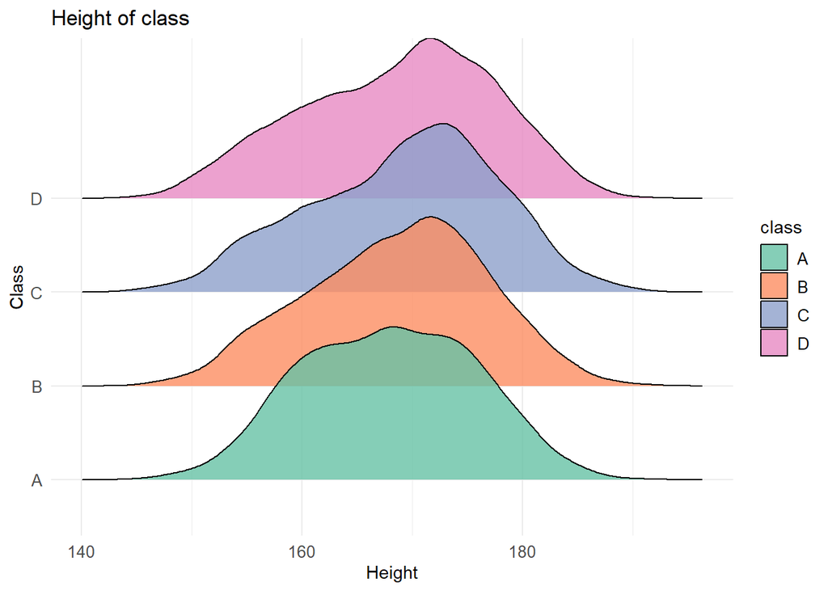

```r
ggplot(data_cleaned, aes(x = height_cm, y = class, fill = class)) +
  geom_density_ridges(alpha = 0.8) +
  theme_minimal() +
  labs(title = "Height of class", x = "Height", y = "Class") +
  scale_fill_brewer(palette = "Set2") +
   theme(
    strip.text = element_text(size = 12),  # Tăng kích thước nhãn facet
    axis.text = element_text(size = 10),   # Tăng kích thước chữ trục
    legend.text = element_text(size = 10) # Tăng kích thước chữ chú thích
  )
```

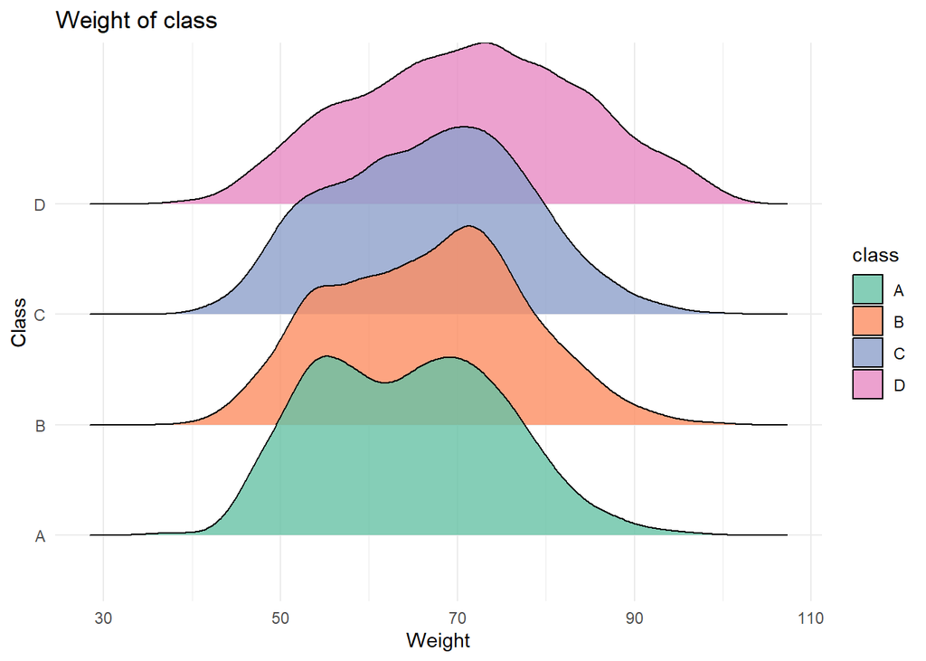

```r
ggplot(data_cleaned, aes(x = weight_kg, y = class, fill = class)) +
  geom_density_ridges(alpha = 0.8) +
  theme_minimal() +
  labs(title = "Weight of class", x = "Weight", y = "Class") +
  scale_fill_brewer(palette = "Set2")
```

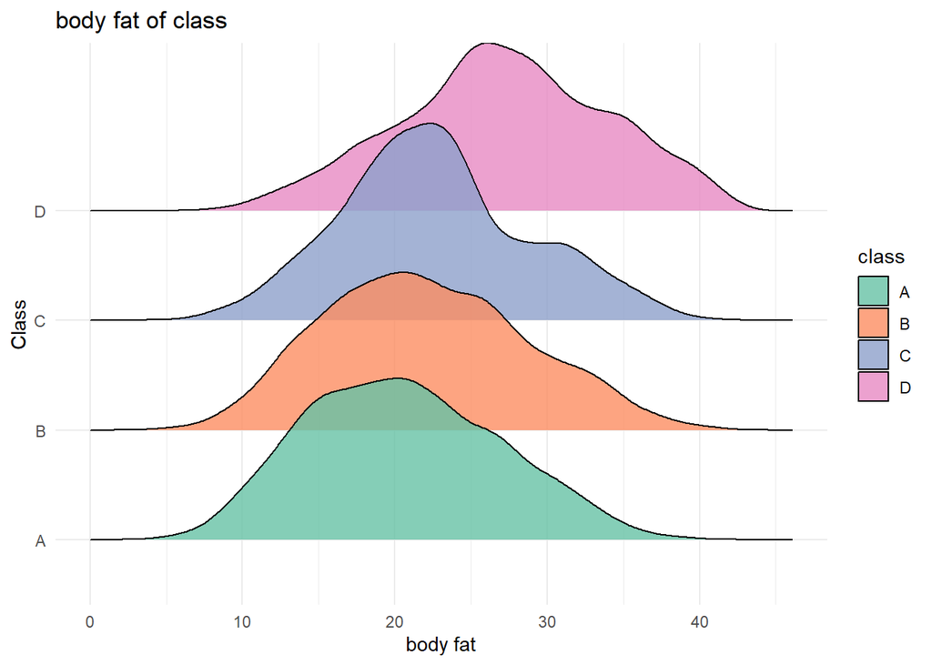

```r
ggplot(data_cleaned, aes(x = body_fat_percent, y = class, fill = class)) +
  geom_density_ridges(alpha = 0.8) +
  theme_minimal() +
  labs(title = "body fat of class", x = "body fat", y = "Class") +
  scale_fill_brewer(palette = "Set2")
```

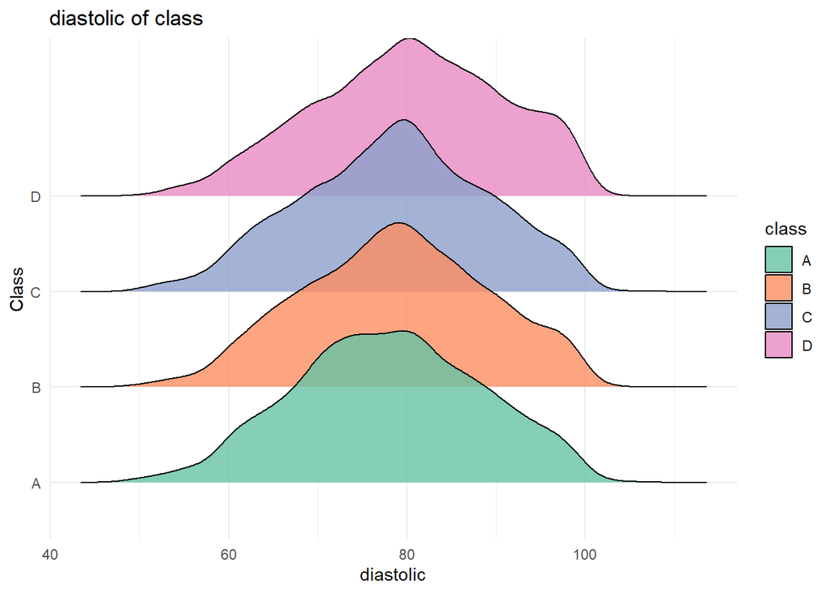

```r
ggplot(data_cleaned, aes(x = diastolic, y = class, fill = class)) +
  geom_density_ridges(alpha = 0.8) +
  theme_minimal() +
  labs(title = "diastolic of class", x = "diastolic", y = "Class") +
  scale_fill_brewer(palette = "Set2")
```

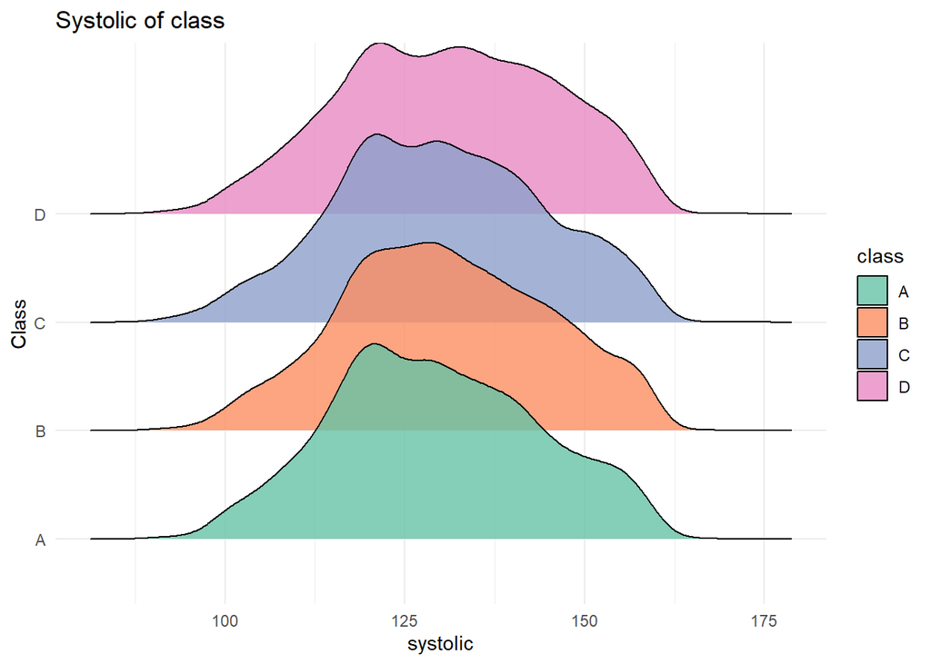

```r
ggplot(data_cleaned, aes(x = systolic, y = class, fill = class)) +
  geom_density_ridges(alpha = 0.8) +
  theme_minimal() +
  labs(title = "Systolic of class", x = "systolic", y = "Class") +
  scale_fill_brewer(palette = "Set2")
```

[figure not shown]

```r
ggplot(data_cleaned, aes(x = grip_force, y = class, fill = class)) +
  geom_density_ridges(alpha = 0.8) +
  theme_minimal() +
  labs(title = "GripForce of class", x = "systolic", y = "Class") +
  scale_fill_brewer(palette = "Set2")
```

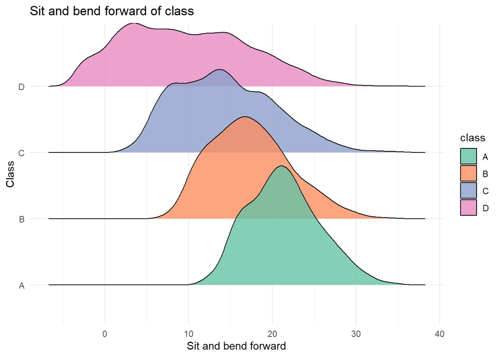

```r
ggplot(data_cleaned, aes(x = sit_and_bend_forward_cm, y = class, fill = class)) +
  geom_density_ridges(alpha = 0.8) +
  theme_minimal() +
  labs(title = "Sit and bend forward of class", x = "Sit and bend forward", y = "Class") +
  scale_fill_brewer(palette = "Set2")
```

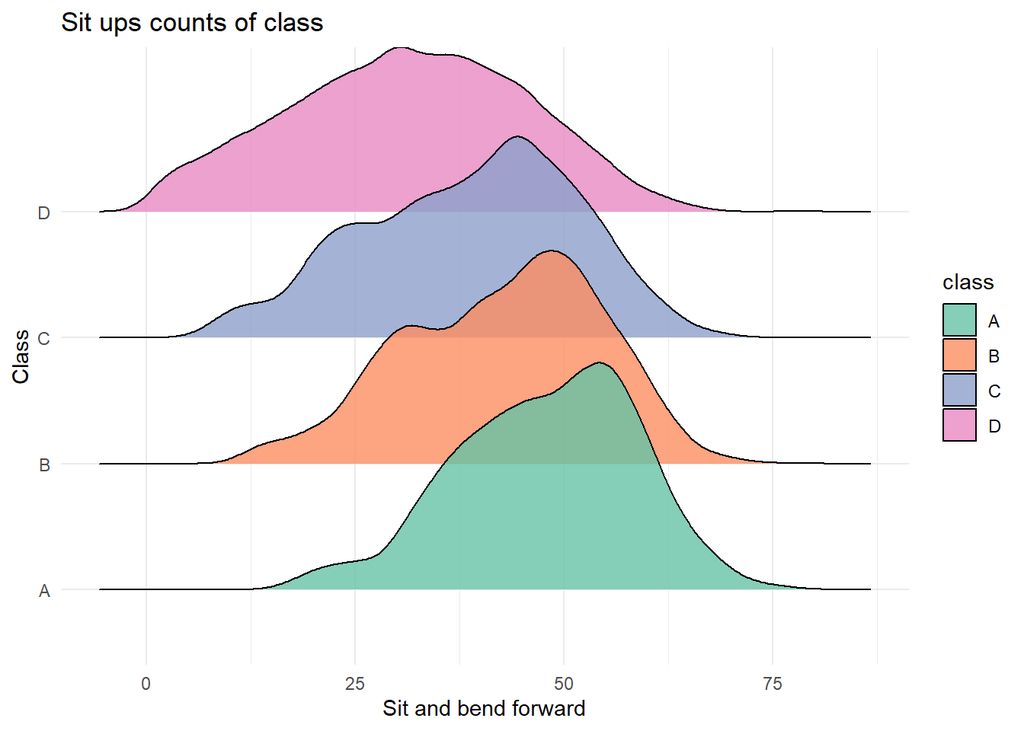

```r
ggplot(data_cleaned, aes(x = sit_ups_counts, y = class, fill = class)) +
  geom_density_ridges(alpha = 0.8) +
  theme_minimal() +
  labs(title = "Sit ups counts of class", x = "Sit and bend forward", y = "Class") +
  scale_fill_brewer(palette = "Set2")
```

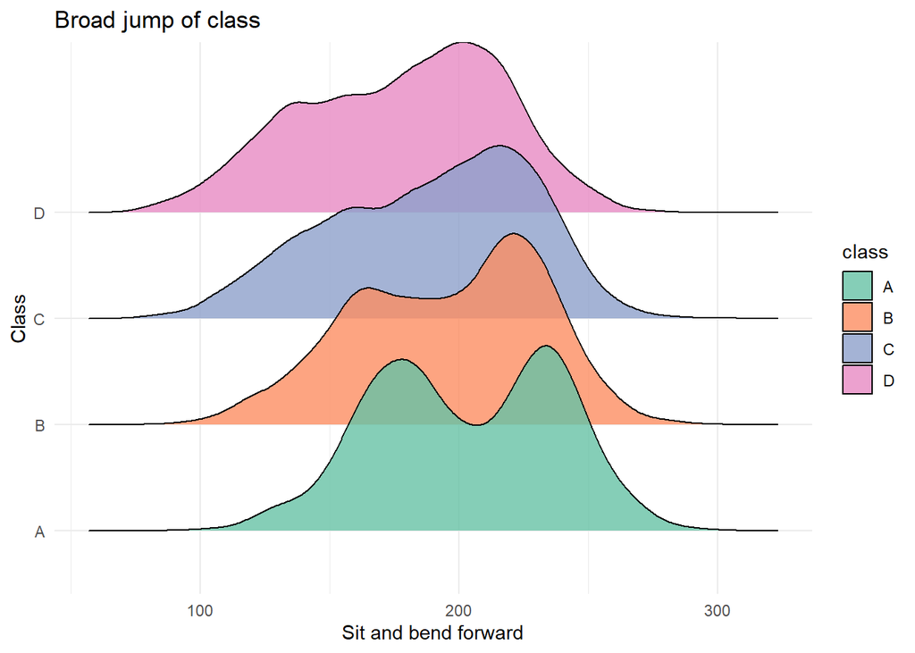

```r
ggplot(data_cleaned, aes(x = broad_jump_cm, y = class, fill = class)) +
  geom_density_ridges(alpha = 0.8) +
  theme_minimal() +
  labs(title = "Broad jump of class", x = "Sit and bend forward", y = "Class") +
  scale_fill_brewer(palette = "Set2")
```

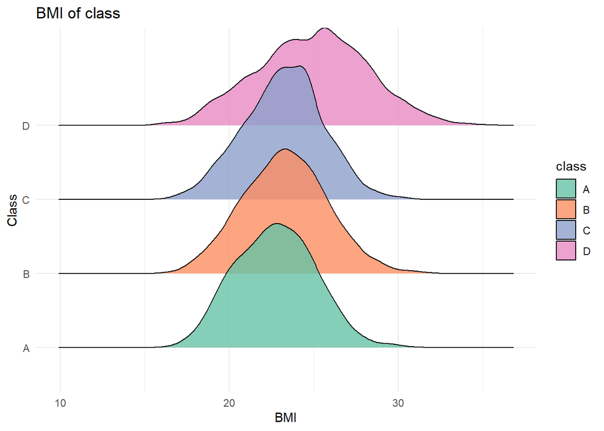

```r
ggplot(data_cleaned, aes(x = BMI, y = class, fill = class)) +
  geom_density_ridges(alpha = 0.8) +
  theme_minimal() +
  labs(title = "BMI of class", x = "BMI", y = "Class") +
  scale_fill_brewer(palette = "Set2")
```

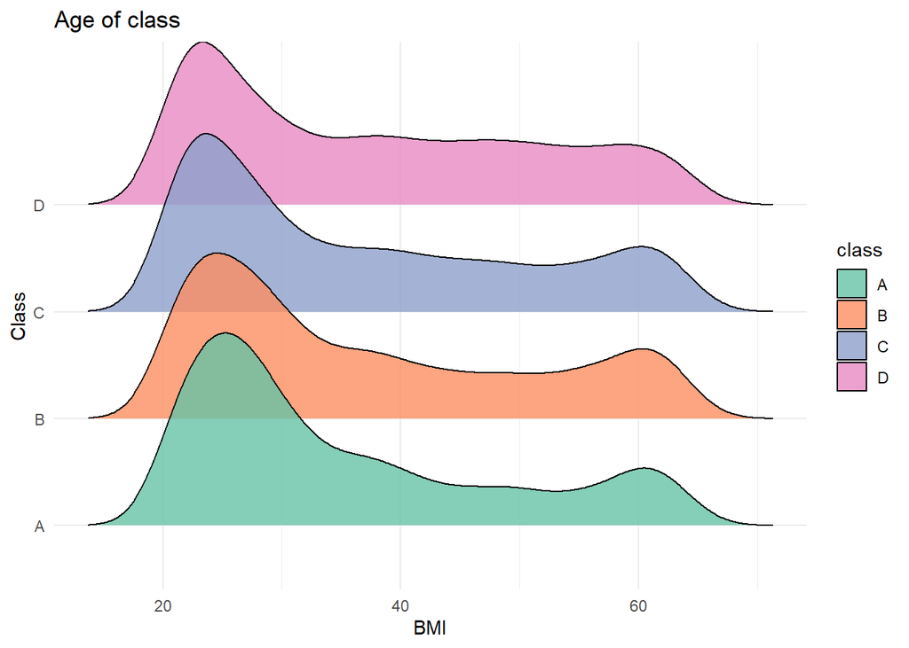

```r
ggplot(data_cleaned, aes(x = age, y = class, fill = class)) +
  geom_density_ridges(alpha = 0.8) +
  theme_minimal() +
  labs(title = "Age of class", x = "BMI", y = "Class") +
  scale_fill_brewer(palette = "Set2")
```

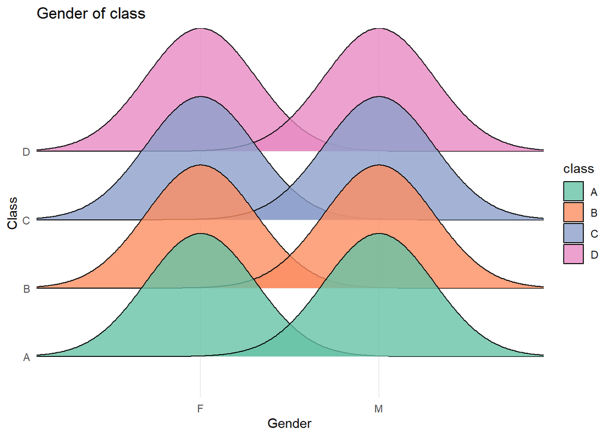

```r
ggplot(data_cleaned, aes(x = gender, y = class, fill = class)) +
  geom_density_ridges(alpha = 0.8) +
  theme_minimal() +
  labs(title = "Gender of class", x = "Gender", y = "Class") +
  scale_fill_brewer(palette = "Set2")
```

## iv Bảng tổng hợp số liệu ### 1. Tổng hợp theo Giới tính (gender)

```r
summary_gender <- data_cleaned %>%
  group_by(gender) %>%
  summarize(
    total_grip_force = sum(grip_force, na.rm = TRUE),
    mean_grip_force = mean(grip_force, na.rm = TRUE),
    median_grip_force = median(grip_force, na.rm = TRUE),
    max_grip_force = max(grip_force, na.rm = TRUE),
    min_grip_force = min(grip_force, na.rm = TRUE)
  )
print(summary_gender)
```

```
## # A tibble: 2 × 6
##   gender total_grip_force mean_grip_force median_grip_force max_grip_force
##   <fct>             <dbl>           <dbl>             <dbl>          <dbl>
## 1 F               120496.            26.0              25.8           45.5
## 2 M               348493.            43.6              43.5           70.5
## # ℹ 1 more variable: min_grip_force <dbl>
```

Kết quả sẽ giúp so sánh hiệu suất lực tay giữa giới tính nam và nữ. ### 2. Tổng hợp theo Loại Hiệu Suất (class)

```r
summary_class <- data_cleaned %>%
  group_by(class) %>%
  summarize(
    total_grip_force = sum(grip_force, na.rm = TRUE),
    mean_grip_force = mean(grip_force, na.rm = TRUE),
    median_grip_force = median(grip_force, na.rm = TRUE),
    max_grip_force = max(grip_force, na.rm = TRUE),
    min_grip_force = min(grip_force, na.rm = TRUE)
  )
print(summary_class)
```

```
## # A tibble: 4 × 6
##   class total_grip_force mean_grip_force median_grip_force max_grip_force
##   <fct>            <dbl>           <dbl>             <dbl>          <dbl>
## 1 A              128061.            38.6              39             70.5
## 2 B              125745.            37.9              39.6           69.9
## 3 C              121649.            36.6              38.0           65.2
## 4 D               93534.            35.1              36             64.1
## # ℹ 1 more variable: min_grip_force <dbl>
```

Giúp xác định nhóm hiệu suất nào có giá trị lực tay cao hơn. ### 3. Tổng hợp theo Nhóm Tuổi

```r
data_cleaned$age_group <- cut(data_cleaned$age, breaks = c(21, 32, 44, 56, 65), right = FALSE)

summary_age_group <- data_cleaned %>%
  group_by(age_group) %>%
  summarize(
    total_grip_force = sum(grip_force, na.rm = TRUE),
    mean_grip_force = mean(grip_force, na.rm = TRUE),
    median_grip_force = median(grip_force, na.rm = TRUE),
    max_grip_force = max(grip_force, na.rm = TRUE),
    min_grip_force = min(grip_force, na.rm = TRUE)
  )
print(summary_age_group)
```

```
## # A tibble: 4 × 6
##   age_group total_grip_force mean_grip_force median_grip_force max_grip_force
##   <fct>                <dbl>           <dbl>             <dbl>          <dbl>
## 1 [21,32)            236263.            38.1              39             70.5
## 2 [32,44)            103399.            39.6              41.6           65.8
## 3 [44,56)             67430.            35.0              35.7           62.9
## 4 [56,65)             61897.            32.9              33.4           59.1
## # ℹ 1 more variable: min_grip_force <dbl>
```

Kết quả sẽ cho biết nhóm tuổi nào có lực tay cao hơn, giúp hiểu rõ hiệu suất giữa các nhóm tuổi. ### 4. Tổng hợp theo Chỉ Số Mỡ Cơ Thể (bodyFat)

```r
data_cleaned$body_fat_group <- cut(data_cleaned$body_fat_percent, breaks = c(0, 15, 25, 100), right = FALSE, labels = c("<15%", "15–25%", ">25%"))

summary_body_fat <- data_cleaned %>%
  group_by(body_fat_group) %>%
  summarize(
    total_grip_force = sum(grip_force, na.rm = TRUE),
    mean_grip_force = mean(grip_force, na.rm = TRUE),
    median_grip_force = median(grip_force, na.rm = TRUE),
    max_grip_force = max(grip_force, na.rm = TRUE),
    min_grip_force = min(grip_force, na.rm = TRUE)
  )
print(summary_body_fat)
```

```
## # A tibble: 3 × 6
##   body_fat_group total_grip_force mean_grip_force median_grip_force
##   <fct>                     <dbl>           <dbl>             <dbl>
## 1 <15%                     74464.            45.1              45.2
## 2 15–25%                  254135.            40.1              41.2
## 3 >25%                    140390.            30.4              27.7
## # ℹ 2 more variables: max_grip_force <dbl>, min_grip_force <dbl>
```

Phân tích này cho thấy mối quan hệ giữa chỉ số mỡ cơ thể và lực tay. ### 5. Tổng hợp theo Chiều Cao (height)

```r
data_cleaned$height_group <- cut(data_cleaned$height_cm, breaks = c(140, 160, 170, 200), right = FALSE, labels = c("<160 cm", "160–170 cm", ">170 cm"))

summary_height <- data_cleaned %>%
  group_by(height_group) %>%
  summarize(
    total_grip_force = sum(grip_force, na.rm = TRUE),
    mean_grip_force = mean(grip_force, na.rm = TRUE),
    median_grip_force = median(grip_force, na.rm = TRUE),
    max_grip_force = max(grip_force, na.rm = TRUE),
    min_grip_force = min(grip_force, na.rm = TRUE)
  )
print(summary_height)
```

```
## # A tibble: 3 × 6
##   height_group total_grip_force mean_grip_force median_grip_force max_grip_force
##   <fct>                   <dbl>           <dbl>             <dbl>          <dbl>
## 1 <160 cm                52904.            24.9              24.5           53.4
## 2 160–170 cm            151560.            33.4              32.3           63.1
## 3 >170 cm               264525.            44.4              44.5           70.5
## # ℹ 1 more variable: min_grip_force <dbl>
```

Giúp hiểu mối quan hệ giữa chiều cao và lực tay. ### 6.Tổng hợp nhịp tim (diastolic) theo class

```r
summary_diastolic <- data_cleaned %>%
  group_by(class) %>%
  summarize(
    total_diastolic = sum(diastolic, na.rm = TRUE),  # Tổng nhịp tim
    mean_diastolic = mean(diastolic, na.rm = TRUE),  # Nhịp tim trung bình
    median_diastolic = median(diastolic, na.rm = TRUE),  # Trung vị nhịp tim
    max_diastolic = max(diastolic, na.rm = TRUE),  # Nhịp tim lớn nhất
    min_diastolic = min(diastolic, na.rm = TRUE)   # Nhịp tim nhỏ nhất
  )

# Hiển thị bảng tổng hợp
print(summary_diastolic)
```

```
## # A tibble: 4 × 6
##   class total_diastolic mean_diastolic median_diastolic max_diastolic
##   <fct>           <dbl>          <dbl>            <dbl>         <dbl>
## 1 A             258579.           77.9               78           106
## 2 B             260887            78.7               79           103
## 3 C             261004            78.6               79           107
## 4 D             213796.           80.2               80           108
## # ℹ 1 more variable: min_diastolic <dbl>
```

### 7.Tổng hợp nhịp tim (systolic) theo class

```r
summary_systolic <- data_cleaned %>%
  group_by(class) %>%
  summarize(
    total_systolic = sum(systolic, na.rm = TRUE),  # Tổng nhịp tim
    mean_systolic = mean(systolic, na.rm = TRUE),  # Nhịp tim trung bình
    median_systolic = median(systolic, na.rm = TRUE),  # Trung vị nhịp tim
    max_systolic = max(systolic, na.rm = TRUE),  # Nhịp tim lớn nhất
    min_systolic = min(systolic, na.rm = TRUE)   # Nhịp tim nhỏ nhất
  )

# Hiển thị bảng tổng hợp
print(summary_systolic)
```

```
## # A tibble: 4 × 6
##   class total_systolic mean_systolic median_systolic max_systolic min_systolic
##   <fct>          <dbl>         <dbl>           <dbl>        <dbl>        <dbl>
## 1 A             428941          129.             128          167           89
## 2 B             432951          131.             130          167           90
## 3 C             431533          130.             130          171           91
## 4 D             349481          131.             131          169           91
```

Các bảng tổng hợp này sẽ cung cấp một cái nhìn tổng quan và chi tiết về các yếu tố ảnh hưởng đến lực tay và hiệu suất cơ thể trong tập dữ liệu bodyPerformance.csv ## v.A/B Testing: ### Kiểm định ANOVA cho từng biến tuân theo phân phối chuẩn Ta thực hiện kiểm định ANOVA cho từng biến tuân theo phân phối chuẩn.

```r
data2$BMI <- calculate_bmi(data2$weight_kg, data2$height_cm)
data2 <- calculate_map(data2, "diastolic", "systolic")
# Thực hiện ANOVA cho từng biến
anova_test <- function(var, data2) {
  formula <- as.formula(paste(var, "~ class"))
  model <- aov(formula, data = data2)
  result <- summary(model)
  return(result[[1]][["Pr(>F)"]][1]) # Trích xuất p-value
}

# Các biến dự đoán
numerical_vars <- c("BMI","MAP", "broad_jump_cm")

# Lặp qua các biến và thu thập p-value
anova_results <- sapply(numerical_vars, function(var) anova_test(var, data2))

# Xuất kết quả ANOVA dưới dạng bảng
print(anova_results, caption = "Kết quả ANOVA cho các biến dự đoán")
```

```
##           BMI           MAP broad_jump_cm
## 1.404499e-309  6.126191e-13 5.649599e-215
```

###Giả thuyết kiểm định cho từng cặp nhóm không theo phân phối chuẩn #### Age

```r
# Thực hiện Dunn Test
dunn_test <- dunnTest(age ~ class, data = data2, method = "bonferroni")
# Hiển thị kết quả
print(dunn_test)
```

```
## Dunn (1964) Kruskal-Wallis multiple comparison
```

```
##   p-values adjusted with the Bonferroni method.
```

```
##   Comparison         Z      P.unadj        P.adj
## 1      A - B -4.698565 2.619954e-06 1.571973e-05
## 2      A - C -2.852461 4.338213e-03 2.602928e-02
## 3      B - C  1.846668 6.479527e-02 3.887716e-01
## 4      A - D -6.844781 7.659277e-12 4.595566e-11
## 5      B - D -2.145354 3.192455e-02 1.915473e-01
## 6      C - D -3.992618 6.534768e-05 3.920861e-04
```

```r
# Thực hiện Dunn Test
dunn_test <- dunnTest(body_fat_percent ~ class, data = data2, method = "bonferroni")
# Hiển thị kết quả
print(dunn_test)
```

```
## Dunn (1964) Kruskal-Wallis multiple comparison
```

```
##   p-values adjusted with the Bonferroni method.
```

```
##   Comparison          Z       P.unadj         P.adj
## 1      A - B  -8.576304  9.797079e-18  5.878247e-17
## 2      A - C -12.036686  2.279297e-33  1.367578e-32
## 3      B - C  -3.458843  5.425009e-04  3.255005e-03
## 4      A - D -38.958483  0.000000e+00  0.000000e+00
## 5      B - D -30.378629 1.052355e-202 6.314133e-202
## 6      C - D -26.923807 1.156226e-159 6.937355e-159
```

```r
# Thực hiện Dunn Test
dunn_test <- dunnTest(grip_force ~ class, data = data2, method = "bonferroni")
# Hiển thị kết quả
print(dunn_test)
```

```
## Dunn (1964) Kruskal-Wallis multiple comparison
```

```
##   p-values adjusted with the Bonferroni method.
```

```
##   Comparison         Z      P.unadj        P.adj
## 1      A - B  2.665996 7.676067e-03 4.605640e-02
## 2      A - C  7.903816 2.704917e-15 1.622950e-14
## 3      B - C  5.237031 1.631802e-07 9.790812e-07
## 4      A - D 14.726286 4.370735e-49 2.622441e-48
## 5      B - D 12.058992 1.738992e-33 1.043395e-32
## 6      C - D  6.822979 8.917141e-12 5.350285e-11
```

```r
# Thực hiện Dunn Test
dunn_test <- dunnTest(sit_and_bend_forward_cm ~ class, data = data2, method = "bonferroni")
# Hiển thị kết quả
print(dunn_test)
```

```
## Dunn (1964) Kruskal-Wallis multiple comparison
```

```
##   p-values adjusted with the Bonferroni method.
```

```
##   Comparison        Z       P.unadj         P.adj
## 1      A - B 25.82111 5.137726e-147 3.082636e-146
## 2      A - C 43.80581  0.000000e+00  0.000000e+00
## 3      B - C 17.97950  2.820450e-72  1.692270e-71
## 4      A - D 67.89141  0.000000e+00  0.000000e+00
## 5      B - D 42.06330  0.000000e+00  0.000000e+00
## 6      C - D 24.08740 3.388326e-128 2.032995e-127
```

```r
# Thực hiện Dunn Test
dunn_test <- dunnTest(sit_ups_counts ~ class, data = data2, method = "bonferroni")
# Hiển thị kết quả
print(dunn_test)
```

```
## Dunn (1964) Kruskal-Wallis multiple comparison
```

```
##   p-values adjusted with the Bonferroni method.
```

```
##   Comparison        Z       P.unadj         P.adj
## 1      A - B 15.97544  1.895012e-57  1.137007e-56
## 2      A - C 27.42899 1.237469e-165 7.424813e-165
## 3      B - C 11.45031  2.343187e-30  1.405912e-29
## 4      A - D 49.35439  0.000000e+00  0.000000e+00
## 5      B - D 33.37407 3.261208e-244 1.956725e-243
## 6      C - D 21.92704 1.434701e-106 8.608204e-106
```

```r
table_data <- table(data2$class, data2$gender)

chisq_test_result <- chisq.test(table_data)
print(chisq_test_result)
```

```
##
##  Pearson's Chi-squared test
##
## data:  table_data
## X-squared = 112.77, df = 3, p-value < 2.2e-16
```

```r
# Vẽ boxplot
# Chia độ tuổi thành nhóm
data2 <- data2 %>%
  mutate(age_group = cut(age, breaks = c(20, 30, 40, 50, 60,70),
                        labels = c("20-30", "30-40", "40-50", "50-60","60-70"),
                        right = FALSE))
```

So sánh chỉ số body_fat_percent của từng nhóm tuổi

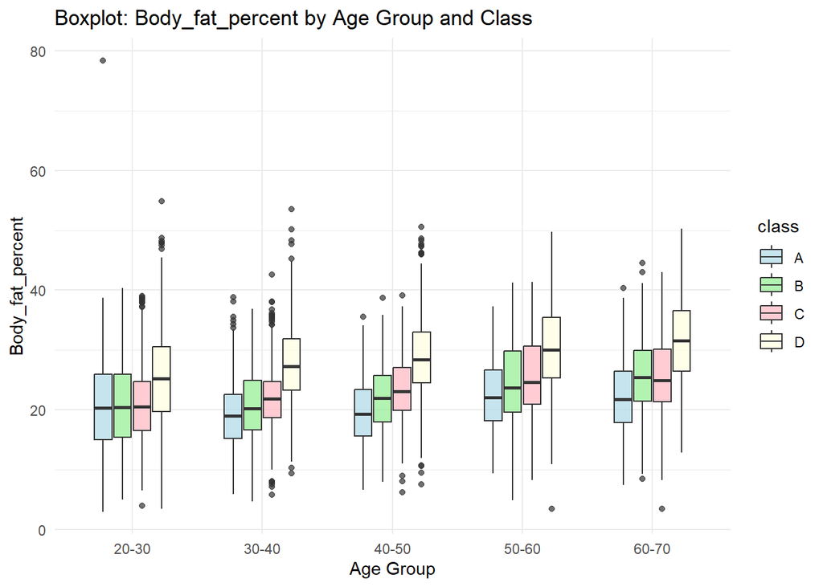

```r
# Vẽ boxplot
ggplot(data2, aes(x = age_group, y = body_fat_percent , fill = class)) +
  geom_boxplot(alpha = 0.7, width = 0.6) +  # Vẽ hộp
  labs(title = "Boxplot: Body_fat_percent by Age Group and Class",
       x = "Age Group",
       y = "Body_fat_percent") +
  scale_fill_manual(values = c("lightblue", "lightgreen", "lightpink", "lightyellow")) +  # Màu sắc cho các class
  theme_minimal()
```

###So sánh chỉ số BMI của từng nhóm tuổi

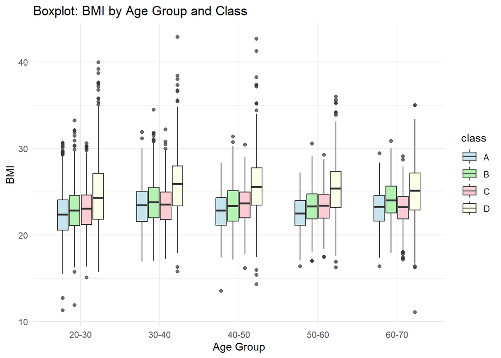

```r
# Vẽ boxplot
ggplot(data2, aes(x = age_group, y =BMI , fill = class)) +
  geom_boxplot(alpha = 0.7, width = 0.6) +  # Vẽ hộp
  labs(title = "Boxplot: BMI by Age Group and Class",
       x = "Age Group",
       y = "BMI") +
  scale_fill_manual(values = c("lightblue", "lightgreen", "lightpink", "lightyellow")) +  # Màu sắc cho các class
  theme_minimal()
```

### Nhận xét chỉ số MAP của từng nhóm tuổi.

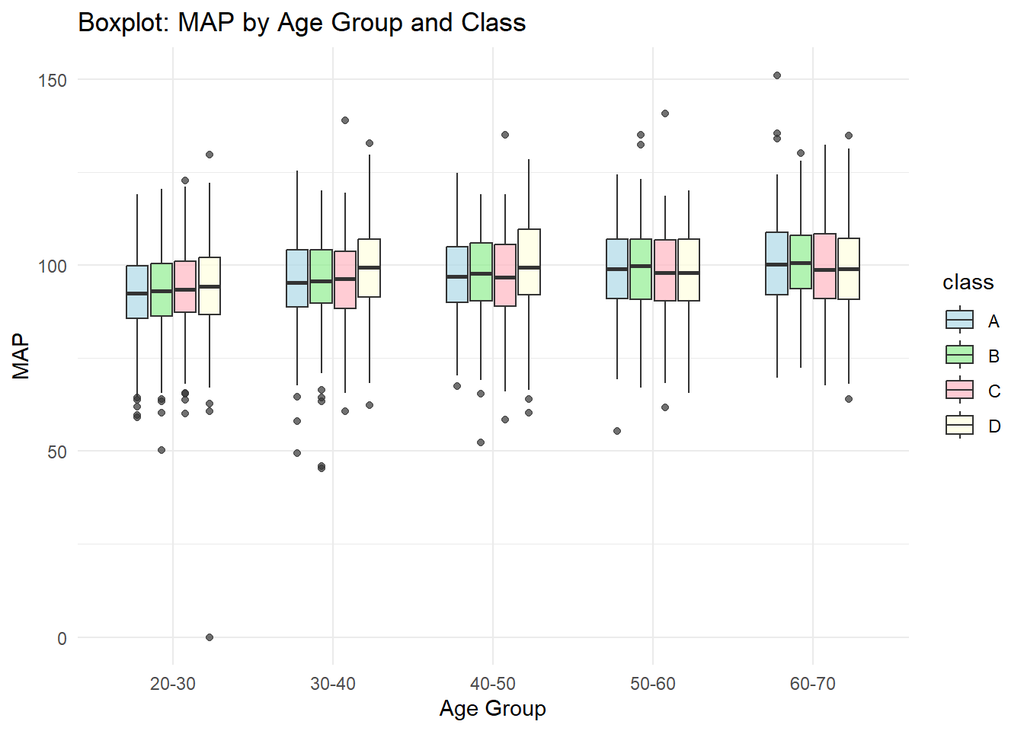

```r
# Vẽ boxplot
ggplot(data2, aes(x = age_group, y =MAP , fill = class)) +
  geom_boxplot(alpha = 0.7, width = 0.6) +  # Vẽ hộp
  labs(title = "Boxplot: MAP by Age Group and Class",
       x = "Age Group",
       y = "MAP") +
  scale_fill_manual(values = c("lightblue", "lightgreen", "lightpink", "lightyellow")) +  # Màu sắc cho các class
  theme_minimal()
```

## vi. Model

```r
#create function
convert_bmi <- function(y){
    if(y < 18.5){
      y <- "Underweight"
    }else
      if(y >= 18.5 & y < 25){
      y <- "Healthy"
    }else
      if(y >= 25 & y < 29.9){
      y <- "Overweight"
    }else{
      y <- "Obese"
    }
}
```

```r
data_cleaned$BMI_status <- sapply (data_cleaned$BMI,
                                  FUN = convert_bmi)
```

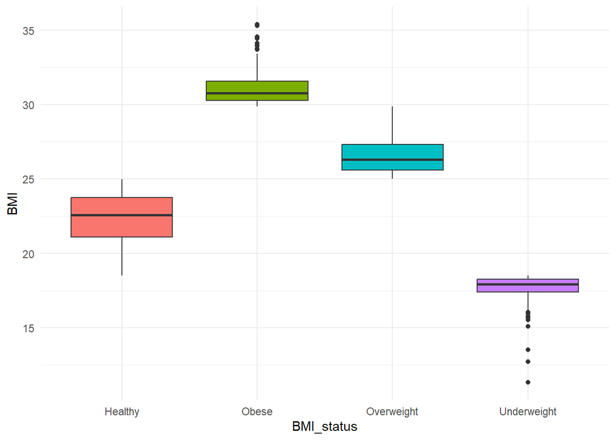

```r
#To check wether the BMI status classification is correct or wrong.
data_cleaned %>%
  ggplot(aes(BMI_status, BMI, fill = BMI_status))+
  geom_boxplot()+
  theme_minimal()+
  theme(legend.position="none")
```

```r
summary(data_cleaned)
```

```
##       age        gender     height_cm       weight_kg      body_fat_percent
##  Min.   :21.00   F:4629   Min.   :144.5   Min.   : 34.50   Min.   : 3.50
##  1st Qu.:25.00   M:7990   1st Qu.:162.5   1st Qu.: 58.10   1st Qu.:17.80
##  Median :32.00            Median :169.2   Median : 67.30   Median :22.50
##  Mean   :36.56            Mean   :168.6   Mean   : 67.06   Mean   :22.86
##  3rd Qu.:47.00            3rd Qu.:174.7   3rd Qu.: 75.00   3rd Qu.:27.60
##  Max.   :64.00            Max.   :191.8   Max.   :101.20   Max.   :42.60
##    diastolic         systolic       grip_force    sit_and_bend_forward_cm
##  Min.   : 49.00   Min.   : 89.0   Min.   : 2.10   Min.   :-3.70
##  1st Qu.: 71.00   1st Qu.:120.0   1st Qu.:27.70   1st Qu.:11.60
##  Median : 79.00   Median :130.0   Median :38.10   Median :16.50
##  Mean   : 78.79   Mean   :130.2   Mean   :37.17   Mean   :16.02
##  3rd Qu.: 86.00   3rd Qu.:141.0   3rd Qu.:45.30   3rd Qu.:21.00
##  Max.   :108.00   Max.   :171.0   Max.   :70.50   Max.   :35.20
##  sit_ups_counts  broad_jump_cm class      age_group         BMI
##  Min.   : 1.00   Min.   : 77   A:3318   [21,32):6197   Min.   :11.31
##  1st Qu.:31.00   1st Qu.:164   B:3314   [32,44):2612   1st Qu.:21.56
##  Median :42.00   Median :195   C:3322   [44,56):1929   Median :23.39
##  Mean   :40.61   Mean   :192   D:2665   [56,65):1881   Mean   :23.46
##  3rd Qu.:51.00   3rd Qu.:222                           3rd Qu.:25.20
##  Max.   :80.00   Max.   :303                           Max.   :35.40
##  body_fat_group     height_group   BMI_status
##  <15%  :1651    <160 cm   :2125   Length:12619
##  15–25%:6344    160–170 cm:4531   Class :character
##  >25%  :4624    >170 cm   :5963   Mode  :character
##
##
##
```

```r
#delete weight, height and BMI column from data frame.
data_cleaned <- data_cleaned %>% dplyr::select(-weight_kg, -height_cm, -BMI)
```

```r
#check N/A
colSums(is.na(data_cleaned))
```

```
##                     age                  gender        body_fat_percent
##                       0                       0                       0
##               diastolic                systolic              grip_force
##                       0                       0                       0
## sit_and_bend_forward_cm          sit_ups_counts           broad_jump_cm
##                       0                       0                       0
##                   class               age_group          body_fat_group
##                       0                       0                       0
##            height_group              BMI_status
##                       0                       0
```

```r
data_cleaned$gender <- as.character(data_cleaned$gender)
data_cleaned$class <- as.character(data_cleaned$class)
data_cleaned$BMI_status <- as.character(data_cleaned$BMI_status)
#Changing several data type and information
data_cleaned$gender[data_cleaned$gender=="M"]<-"0"
data_cleaned$gender[data_cleaned$gender=="F"]<-"1"
data_cleaned$class[data_cleaned$class=="A"]<-"0"
data_cleaned$class[data_cleaned$class=="B"]<-"1"
data_cleaned$class[data_cleaned$class=="C"]<-"2"
data_cleaned$class[data_cleaned$class=="D"]<-"3"
data_cleaned$BMI_status[data_cleaned$BMI_status=="Underweight"]<- "0"
data_cleaned$BMI_status[data_cleaned$BMI_status=="Healthy"]<- "1"
data_cleaned$BMI_status[data_cleaned$BMI_status=="Overweight"]<- "2"
data_cleaned$BMI_status[data_cleaned$BMI_status=="Obese"]<- "3"

data_cleaned <- data_cleaned %>% mutate_if(is.character, as.factor)

# Lọc các dòng có 'class' bằng 0 (df_accepted)
df_accepted <- data_cleaned[data_cleaned$class == 0, ]

# Loại bỏ các dòng có 'class' bằng 0 (df_denied)
df_denied <- data_cleaned[!(data_cleaned$class == 0), ]

# Cập nhật lại giá trị của cột 'class' thành 1 trong df_denied
df_denied$class <- 1

# Thêm 3318 dòng từ df_denied vào df_accepted
data_cleaned_1 <- rbind(df_accepted, head(df_denied, 3318))

# Trộn ngẫu nhiên các dòng trong df2
data_cleaned_1 <- data_cleaned_1[sample(nrow(data_cleaned_1)), ]


data_cleaned_1 <- data_cleaned_1[, !(names(data_cleaned_1) %in% c("age", "gender"))]
```

```r
calculate_map <- function(data, diastolic, systolic) {
  # Kiểm tra các cột có tồn tại trong dữ liệu
  if (!(diastolic %in% names(data)) || !(systolic %in% names(data))) {
    stop("Cột diastolic hoặc systolic không tồn tại trong dữ liệu.")
  }

  data$MAP <- data[[diastolic]] + (data[[systolic]] - data[[diastolic]]) / 3
  return(data)
}

data_cleaned_1 <- calculate_map(data_cleaned_1, "diastolic", "systolic")
```

```r
#check dataframe performance
glimpse(data_cleaned_1)
```

```
## Rows: 6,636
## Columns: 13
## $ body_fat_percent        <dbl> 21.5, 21.7, 7.2, 24.5, 27.0, 33.9, 23.1, 15.4,…
## $ diastolic               <dbl> 82, 72, 90, 77, 99, 81, 72, 70, 67, 96, 80, 71…
## $ systolic                <dbl> 137, 126, 141, 146, 159, 142, 120, 125, 123, 1…
## $ grip_force              <dbl> 44.2, 38.8, 46.4, 47.0, 48.8, 22.8, 45.7, 45.0…
## $ sit_and_bend_forward_cm <dbl> 9.4, 9.5, 28.2, 12.9, 9.9, 19.9, 18.1, 21.0, 1…
## $ sit_ups_counts          <dbl> 32, 54, 56, 58, 33, 40, 60, 57, 63, 47, 45, 38…
## $ broad_jump_cm           <dbl> 210, 226, 251, 199, 205, 162, 195, 235, 228, 2…
## $ class                   <fct> 1, 1, 0, 1, 1, 0, 0, 0, 0, 1, 1, 1, 1, 1, 1, 0…
## $ age_group               <fct> "[44,56)", "[21,32)", "[21,32)", "[21,32)", "[…
## $ body_fat_group          <fct> 15–25%, 15–25%, <15%, 15–25%, >25%, >25%, 15–2…
## $ height_group            <fct> >170 cm, >170 cm, >170 cm, >170 cm, >170 cm, <…
## $ BMI_status              <fct> 1, 2, 1, 2, 2, 1, 2, 1, 1, 1, 2, 1, 1, 1, 1, 1…
## $ MAP                     <dbl> 100.33333, 90.00000, 107.00000, 100.00000, 119…
```

```r
# checking proportion of target variable
prop.table(table(data_cleaned$class))
```

```
##
##         0         1         2         3
## 0.2629368 0.2626199 0.2632538 0.2111895
```

```r
table(data_cleaned_1$class)
```

```
##
##    0    1    2    3
## 3318 3318    0    0
```

```r
# Chia dữ liệu thành tập huấn luyện (80%) và tập kiểm tra (20%)
set.seed(120)
index <- initial_split(data_cleaned_1, prop = 0.8, strata = "class")
data_train <- training(index)
data_test <- testing(index)
data_train$class <- droplevels(data_train$class)
```

```r
#Create Random Forest Model
model_rf_1 <- randomForest(class ~ body_fat_percent+ grip_force + sit_and_bend_forward_cm + sit_ups_counts +broad_jump_cm +BMI_status + MAP,
                         data = data_train,
                         importance = TRUE,
                         ntree = 500)
model_rf_1
```

```
##
## Call:
##  randomForest(formula = class ~ body_fat_percent + grip_force +      sit_and_bend_forward_cm + sit_ups_counts + broad_jump_cm +      BMI_status + MAP, data = data_train, importance = TRUE, ntree = 500)
##                Type of random forest: classification
##                      Number of trees: 500
## No. of variables tried at each split: 2
##
##         OOB estimate of  error rate: 18.65%
## Confusion matrix:
##      0    1 class.error
## 0 2320  334   0.1258478
## 1  656 1998   0.2471741
```

```r
#predicttion using Random Forest model in training data
data_mod1 <- predict(model_rf_1,
                    newdata = data_test)
```

```r
#Confusion matrix result
confusionMatrix(data = data_mod1,
                reference = data_test$class)
```

```
## Confusion Matrix and Statistics
##
##           Reference
## Prediction   0   1   2   3
##          0 571 152   0   0
##          1  93 512   0   0
##          2   0   0   0   0
##          3   0   0   0   0
##
## Overall Statistics
##
##                Accuracy : 0.8155
##                  95% CI : (0.7936, 0.836)
##     No Information Rate : 0.5
##     P-Value [Acc > NIR] : < 2.2e-16
##
##                   Kappa : 0.631
##
##  Mcnemar's Test P-Value : NA
##
## Statistics by Class:
##
##                      Class: 0 Class: 1 Class: 2 Class: 3
## Sensitivity            0.8599   0.7711       NA       NA
## Specificity            0.7711   0.8599        1        1
## Pos Pred Value         0.7898   0.8463       NA       NA
## Neg Pred Value         0.8463   0.7898       NA       NA
## Prevalence             0.5000   0.5000        0        0
## Detection Rate         0.4300   0.3855        0        0
## Detection Prevalence   0.5444   0.4556        0        0
## Balanced Accuracy      0.8155   0.8155       NA       NA
```

```r
set.seed(123)

trainIndex <- createDataPartition(data_cleaned_1$class, p = 0.8, list = FALSE)
trainData <- data_cleaned_1[trainIndex, ]
testData <- data_cleaned_1[-trainIndex, ]
str(trainData)
```

```
## tibble [5,310 × 13] (S3: tbl_df/tbl/data.frame)
##  $ body_fat_percent       : num [1:5310] 21.5 21.7 7.2 24.5 33.9 15.4 9.7 23.4 20 29 ...
##  $ diastolic              : num [1:5310] 82 72 90 77 81 70 67 96 80 78 ...
##  $ systolic               : num [1:5310] 137 126 141 146 142 125 123 146 120 111 ...
##  $ grip_force             : num [1:5310] 44.2 38.8 46.4 47 22.8 45 44.5 41.6 54.4 22.1 ...
##  $ sit_and_bend_forward_cm: num [1:5310] 9.4 9.5 28.2 12.9 19.9 21 15.8 13.2 17.2 19.5 ...
##  $ sit_ups_counts         : num [1:5310] 32 54 56 58 40 57 63 47 45 47 ...
##  $ broad_jump_cm          : num [1:5310] 210 226 251 199 162 235 228 218 222 197 ...
##  $ class                  : Factor w/ 4 levels "0","1","2","3": 2 2 1 2 1 1 1 2 2 2 ...
##  $ age_group              : Factor w/ 4 levels "[21,32)","[32,44)",..: 3 1 1 1 1 1 1 3 1 1 ...
##  $ body_fat_group         : Factor w/ 3 levels "<15%","15–25%",..: 2 2 1 2 3 2 1 2 2 3 ...
##  $ height_group           : Factor w/ 3 levels "<160 cm","160–170 cm",..: 3 3 3 3 1 2 3 3 3 2 ...
##  $ BMI_status             : Factor w/ 4 levels "0","1","2","3": 2 3 2 3 2 2 2 2 3 2 ...
##  $ MAP                    : num [1:5310] 100 90 107 100 101 ...
```

```r
model <- nnet::multinom(class ~body_fat_percent+ grip_force + sit_and_bend_forward_cm + sit_ups_counts +broad_jump_cm +BMI_status + MAP,
                  data = trainData)
# Hiển thị tóm tắt mô hình
summary(model)
```

```
## Call:
## nnet::multinom(formula = class ~ body_fat_percent + grip_force +
##     sit_and_bend_forward_cm + sit_ups_counts + broad_jump_cm +
##     BMI_status + MAP, data = trainData)
##
## Coefficients:
##                                Values   Std. Err.
## (Intercept)              6.2295314129 0.553221586
## body_fat_percent         0.0441313440 0.008406995
## grip_force              -0.0335108974 0.006306748
## sit_and_bend_forward_cm -0.2706008044 0.008890282
## sit_ups_counts          -0.0711128778 0.004689619
## broad_jump_cm            0.0106812146 0.001991550
## BMI_status1             -0.1169222842 0.218351193
## BMI_status2              0.4595071014 0.249054719
## BMI_status3              1.9084825431 0.573411227
## MAP                     -0.0002015742 0.003538520
##
## Residual Deviance: 4714.823
## AIC: 4734.823
```

```r
# Bước 5: Dự đoán và đánh giá mô hình
predictions <- predict(model, newdata = testData)

# Tạo ma trận nhầm lẫn và tính độ chính xác
conf_mat <- confusionMatrix(predictions, testData$class)
print(conf_mat)
```

```
## Confusion Matrix and Statistics
##
##           Reference
## Prediction   0   1   2   3
##          0 553 157   0   0
##          1 110 506   0   0
##          2   0   0   0   0
##          3   0   0   0   0
##
## Overall Statistics
##
##                Accuracy : 0.7986
##                  95% CI : (0.776, 0.8199)
##     No Information Rate : 0.5
##     P-Value [Acc > NIR] : < 2.2e-16
##
##                   Kappa : 0.5973
##
##  Mcnemar's Test P-Value : NA
##
## Statistics by Class:
##
##                      Class: 0 Class: 1 Class: 2 Class: 3
## Sensitivity            0.8341   0.7632       NA       NA
## Specificity            0.7632   0.8341        1        1
## Pos Pred Value         0.7789   0.8214       NA       NA
## Neg Pred Value         0.8214   0.7789       NA       NA
## Prevalence             0.5000   0.5000        0        0
## Detection Rate         0.4170   0.3816        0        0
## Detection Prevalence   0.5354   0.4646        0        0
## Balanced Accuracy      0.7986   0.7986       NA       NA
```

```r
# Độ chính xác
accuracy <- conf_mat$overall["Accuracy"]
print(paste("Accuracy:", accuracy))
```

```
## [1] "Accuracy: 0.798642533936652"
```